# Indian Housing Consumption Expenses

Author

Ágatha del Olmo Tirado

Published

October 18, 2024

1. households.csv: Contains information on unique identifier for each household (hh_id), survey weight for each household (weight), whether the household is in urban or rural region (urban), and number of members in the household (hh_size)

Survey data weighting is a statistical technique used in market research to adjust survey results to accurately represent the target population. To ensure that the sample accurately reflects the larger population. This is done to minimize bias and increase survey results reliability and validity of survey results.

2. expenses.csv: Contains information on annual expenditure (annual_expenditure) by each household (hh_id) on different products, each product being labeled with a unique identifier (product_id)
3. products.csv: Contains information on the name (product_name_en) of every product consumed by the households (product_id), and the COICOP 1999 classification of each product by 4 levels (coicop_survey_1, coicop_survey_2, coicop_survey_3, coicop_survey_4)

```r
library(rcartocolor)
library(dplyr)
library(ggplot2)
library(lawstat)
library(kableExtra)

colores <- carto_pal(12, "Teal")
colores2 <- carto_pal(12, "RedOr")
```

```r
expenses <- read.csv("./expenses.csv")
households <- read.csv("./households.csv")
products <- read.csv("./products.csv")

data <- expenses %>%
  left_join(products, by = "product_id") %>%
  left_join(households, by = "hh_id")

data <- data %>%
  mutate(weighted_expenditure = annual_expenditure * weight)
```

```r
Tabla.urban <- table(data$urban)

Tabla.urban <- round(Tabla.urban/nrow(data)*100,2)

Tabla.urban %>%
  kbl(col.names = c("HouseHold", "Proportion"),
      align = rep('c', 2)) %>%
  kable_styling()
```

| HouseHold | Proportion |
| --- | --- |
| Rural | 57.67 |
| Urban | 42.33 |

```r
#in spain (and very constant in neurope too) 80% in urban areas
```

```r
national_spending <- data %>%
  group_by(coicop_survey_1) %>%
  summarize(total_weighted_expenditure = sum(weighted_expenditure, na.rm = TRUE))

national_spending
```

```
# A tibble: 12 × 2
   coicop_survey_1 total_weighted_expenditure
             <int>                      <dbl>
 1               1                    2.92e15
 2               2                    1.90e14
 3               3                    4.27e14
 4               4                    1.25e15
 5               5                    2.91e14
 6               6                    4.51e14
 7               7                    6.18e14
 8               8                    1.91e14
 9               9                    1.73e14
10              10                    2.45e14
11              11                    1.34e12
12              12                    3.33e14
```

```r
national_spending <- national_spending %>%
  mutate(share = total_weighted_expenditure / sum(total_weighted_expenditure))

national_spending
```

```
# A tibble: 12 × 3
   coicop_survey_1 total_weighted_expenditure    share
             <int>                      <dbl>    <dbl>
 1               1                    2.92e15 0.412
 2               2                    1.90e14 0.0268
 3               3                    4.27e14 0.0602
 4               4                    1.25e15 0.176
 5               5                    2.91e14 0.0410
 6               6                    4.51e14 0.0636
 7               7                    6.18e14 0.0872
 8               8                    1.91e14 0.0270
 9               9                    1.73e14 0.0244
10              10                    2.45e14 0.0345
11              11                    1.34e12 0.000189
12              12                    3.33e14 0.0470
```

```r
round(sum(national_spending$share),2)==1
```

```
[1] TRUE
```

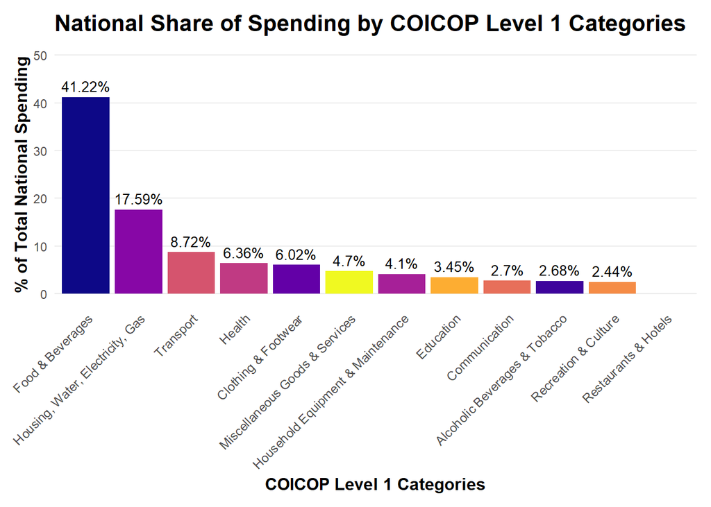

```r
national_spending_forplot <- national_spending %>%
  mutate(percentage = round(share * 100, 2)) %>%
  arrange(desc(share))

category_labels <- c(
  "1" = "Food & Beverages",
  "2" = "Alcoholic Beverages & Tobacco",
  "3" = "Clothing & Footwear",
  "4" = "Housing, Water, Electricity, Gas",
  "5" = "Household Equipment & Maintenance",
  "6" = "Health",
  "7" = "Transport",
  "8" = "Communication",
  "9" = "Recreation & Culture",
  "10" = "Education",
  "11" = "Restaurants & Hotels",
  "12" = "Miscellaneous Goods & Services"
)

national_spending_forplot$coicop_survey_1 <- factor(national_spending_forplot$coicop_survey_1)

p <-ggplot(national_spending_forplot, aes(x = reorder(coicop_survey_1, -percentage), y = percentage, fill = coicop_survey_1)) +
  geom_bar(stat = "identity", show.legend = FALSE) +
  scale_fill_viridis_d(option = "C") +
  labs(
    title = "National Share of Spending by COICOP Level 1 Categories",
    x = "COICOP Level 1 Categories",
    y = "% of Total National Spending",
  ) +
  theme_minimal() +
  theme(
    axis.text.x = element_text(angle = 45, hjust = 1, size = 9),
    axis.title.x = element_text(size = 12, face = "bold"),
    axis.title.y = element_text(size = 12, face = "bold"),
    plot.title = element_text(size = 16, face = "bold"),
    plot.subtitle = element_text(size = 12),
    plot.caption = element_text(size = 10, face = "italic"),
    panel.grid.major.x = element_blank(),
    panel.grid.minor = element_blank(),
    plot.margin = margin(10, 10, 10, 10),
    plot.background = element_rect(fill = "white", color = NA),  # White background, no border
    panel.background = element_rect(fill = "white", color = NA)  # White panel background
) +
  geom_text(aes(label = ifelse(percentage > 2, paste0(percentage, "%"), "")),
            vjust = -0.5, size = 3.5, color = "black") +
  scale_x_discrete(labels = category_labels) +
  expand_limits(y = c(0, 50)) +
  coord_cartesian(clip = 'off')

p
```

```r
#ggsave("plot.tiff", plot = p, device = "tiff", width = 7, height = 4.32, dpi = 300)
```

```r
households_grouped <- households %>%
  inner_join(expenses %>% group_by(hh_id) %>% summarize(total_expenditure = sum(annual_expenditure)), by = "hh_id") %>%
  mutate(per_capita_expenditure = total_expenditure / hh_size) %>%
  arrange(per_capita_expenditure)

head(households_grouped)
```

```
              hh_id weight urban hh_size total_expenditure
1 IND-2022-33802314 130882 Urban       3          3550.000
2 IND-2022-69894311 259645 Rural       1          2250.833
3 IND-2022-67452312 215726 Rural       1          4078.381
4 IND-2022-32932304  50981 Urban       1          4605.833
5 IND-2022-63137312 111453 Rural      11         51452.762
6 IND-2022-66357307  67519 Rural       1          4753.333
  per_capita_expenditure
1               1183.333
2               2250.833
3               4078.381
4               4605.833
5               4677.524
6               4753.333
```

```r
households_grouped <- households_grouped %>%
  mutate(weighted_population = hh_size * weight,
         cumulative_population = cumsum(as.numeric(weighted_population)),
         cumulative_population_share = cumulative_population / sum(as.numeric(weighted_population), na.rm = TRUE),
         cumulative_expenditure_share = cumsum(total_expenditure * weight) / sum(total_expenditure * weight))

#had to convert some to as.numeric bc of integer overflow
colSums(is.na(households_grouped)) #now perfect, no na
```

```
                       hh_id                       weight
                           0                            0
                       urban                      hh_size
                           0                            0
           total_expenditure       per_capita_expenditure
                           0                            0
         weighted_population        cumulative_population
                           0                            0
 cumulative_population_share cumulative_expenditure_share
                           0                            0
```

```r
head(households_grouped)
```

```
              hh_id weight urban hh_size total_expenditure
1 IND-2022-33802314 130882 Urban       3          3550.000
2 IND-2022-69894311 259645 Rural       1          2250.833
3 IND-2022-67452312 215726 Rural       1          4078.381
4 IND-2022-32932304  50981 Urban       1          4605.833
5 IND-2022-63137312 111453 Rural      11         51452.762
6 IND-2022-66357307  67519 Rural       1          4753.333
  per_capita_expenditure weighted_population cumulative_population
1               1183.333              392646                392646
2               2250.833              259645                652291
3               4078.381              215726                868017
4               4605.833               50981                918998
5               4677.524             1225983               2144981
6               4753.333               67519               2212500
  cumulative_population_share cumulative_expenditure_share
1                3.224361e-06                 6.550863e-08
2                5.356534e-06                 1.479060e-07
3                7.128049e-06                 2.719514e-07
4                7.546699e-06                 3.050574e-07
5                1.761432e-05                 1.113577e-06
6                1.816878e-05                 1.158827e-06
```

```r
tail(households_grouped$cumulative_population_share, 1)
```

```
[1] 1
```

```r
tail(households_grouped$cumulative_expenditure_share, 1)
```

```
[1] 1
```

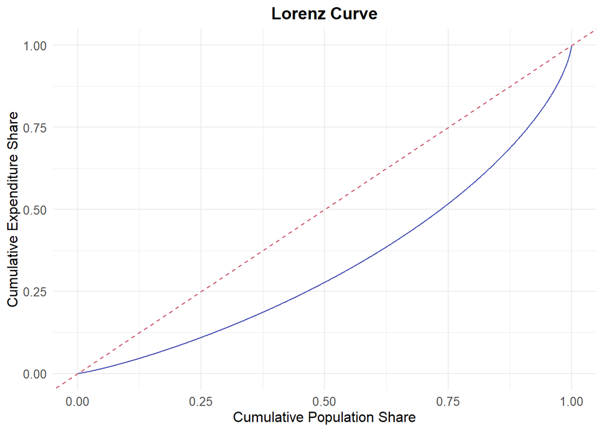

```r
p2 <- ggplot(households_grouped, aes(x = cumulative_population_share, y = cumulative_expenditure_share)) +
  geom_line(color = "#3f49b0") +
  geom_abline(intercept = 0, slope = 1, color = colores2[10], linetype = "dashed") +
  labs(title = "Lorenz Curve", x = "Cumulative Population Share", y = "Cumulative Expenditure Share")+
  theme_minimal() +
  theme(
    plot.title = element_text(hjust = 0.5, size = 14, face = "bold"),
    axis.title = element_text(size = 12),
    axis.text = element_text(size = 10),
    plot.background = element_rect(fill = "white", color = NA),  # White background, no border
    panel.background = element_rect(fill = "white", color = NA)  # White panel background

  )

p2
```

```r
#ggsave("plot2.tiff", plot = p2, device = "tiff", width = 7, height = 4.32, dpi = 300)
```

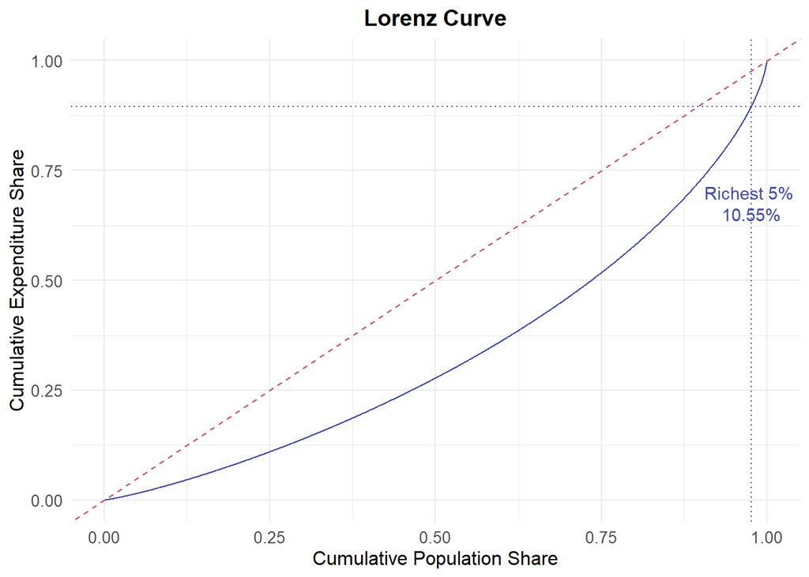

```r
richest_5_percent <- households_grouped %>%
  tail(floor(0.05 * nrow(households_grouped)))

richest_5_percent_cutoff <- richest_5_percent$cumulative_population_share[1]
richest_expenditure_share <- richest_5_percent$cumulative_expenditure_share[1]

actual_richest_expenditure_share <- 1-richest_expenditure_share

households_grouped_forplot <- households_grouped %>%
  mutate(cumulative_population_share = cumsum(as.numeric(hh_size * weight)) / sum(hh_size * weight),
         cumulative_expenditure_share = cumsum(as.numeric(total_expenditure * weight)) / sum(total_expenditure * weight))

p3 <- ggplot(households_grouped_forplot, aes(x = cumulative_population_share, y = cumulative_expenditure_share)) +
  geom_line(color = "#3f49b0") +
  labs(title = "Lorenz Curve", x = "Cumulative Population Share", y = "Cumulative Expenditure Share")+
  geom_abline(intercept = 0, slope = 1, color = colores2[10], linetype = "dashed") +
  geom_vline(xintercept = richest_5_percent_cutoff, color = "#3f49b0", linetype = "dotted") +
  geom_hline(yintercept = richest_expenditure_share, color = "#3f49b0", linetype = "dotted") +
  annotate("text", x = richest_5_percent_cutoff, y = 0.7,
           label = paste("Richest 5% ", sep=""), color = "#3f49b0") +
  annotate("text", x = richest_5_percent_cutoff, y = 0.65,
           label = paste(round(actual_richest_expenditure_share * 100, 2), "%", sep=""), color = "#3f49b0")+
  theme_minimal() +
  theme(
    plot.title = element_text(hjust = 0.5, size = 14, face = "bold"),
    axis.title = element_text(size = 12),
    axis.text = element_text(size = 10),
    plot.background = element_rect(fill = "white", color = NA),  # White background, no border
    panel.background = element_rect(fill = "white", color = NA)  # White panel background

  )

p3
```

```r
#ggsave("plot3.tiff", plot = p3, device = "tiff", width = 7, height = 4.32, dpi = 300)
```

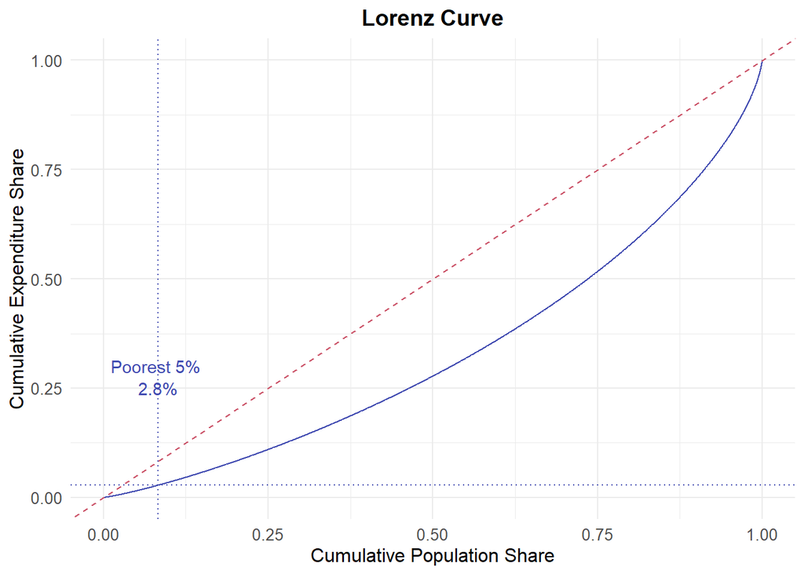

```r
poorest_5_percent <- households_grouped %>%
  head(floor(0.05 * nrow(households_grouped)))

# Calculate the cutoff and expenditure share for the poorest 5%
poorest_5_percent_cutoff <- poorest_5_percent$cumulative_population_share[nrow(poorest_5_percent)]
poorest_expenditure_share <- poorest_5_percent$cumulative_expenditure_share[nrow(poorest_5_percent)]

# The actual share for the poorest 5% will be equal to the cumulative expenditure share at the cutoff
actual_poorest_expenditure_share <- poorest_expenditure_share

# Plot for the Lorenz Curve with the poorest 5% highlighted
p4 <- ggplot(households_grouped_forplot, aes(x = cumulative_population_share, y = cumulative_expenditure_share)) +
  geom_line(color = "#3f49b0") +
  labs(title = "Lorenz Curve", x = "Cumulative Population Share", y = "Cumulative Expenditure Share") +
  geom_abline(intercept = 0, slope = 1, color = colores2[10], linetype = "dashed") +
  geom_vline(xintercept = poorest_5_percent_cutoff, color = "#3f49b0", linetype = "dotted") + # Vertical line for the poorest 5%
  geom_hline(yintercept = poorest_expenditure_share, color = "#3f49b0", linetype = "dotted") + # Horizontal line for the poorest 5% expenditure share
  annotate("text", x = poorest_5_percent_cutoff, y = 0.3,
           label = paste("Poorest 5% ", sep=""), color = "#3f49b0") +
  annotate("text", x = poorest_5_percent_cutoff, y = 0.25,
           label = paste(round(actual_poorest_expenditure_share * 100, 2), "%", sep=""), color = "#3f49b0") +
  theme_minimal() +
  theme(
    plot.title = element_text(hjust = 0.5, size = 14, face = "bold"),
    axis.title = element_text(size = 12),
    axis.text = element_text(size = 10),
    plot.background = element_rect(fill = "white", color = NA),  # White background, no border
    panel.background = element_rect(fill = "white", color = NA)  # White panel background

  )

p4
```

```r
#ggsave("plot4.tiff", plot = p4, device = "tiff", width = 7, height = 4.32, dpi = 300)
```

```r
lorenz <- households_grouped[,9:10]
head(lorenz)
```

```
  cumulative_population_share cumulative_expenditure_share
1                3.224361e-06                 6.550863e-08
2                5.356534e-06                 1.479060e-07
3                7.128049e-06                 2.719514e-07
4                7.546699e-06                 3.050574e-07
5                1.761432e-05                 1.113577e-06
6                1.816878e-05                 1.158827e-06
```

```r
lorenz_area <- sum((lorenz$cumulative_expenditure_share[-1] + #all values except the first
                    lorenz$cumulative_expenditure_share[-nrow(lorenz)]) * #all values except the last
                    diff(lorenz$cumulative_population_share)) / 2 #differences between consecutive population shares

lorenz_area
```

```
[1] 0.3324944
```

```r
gini_coefficient <-  (0.5 - lorenz_area) / 0.5 #0.5 is 45º, the line of equality
gini_coefficient
```

```
[1] 0.3350113
```